# Test RISC on real datasets. Pseudo-batches

Martin Loza

On this workflow I will correct batch-effect on the pseudo-batches dataset described in the Canek paper. This test aims to asses the bias introduced by integration tools in the absent of batch-effects.

```r
library(Seurat)
library(RISC)
library(ggplot2)
library(splatter)
library(patchwork)
library(here)
library(kBET)
library(ggrepel)
source(here("ScRNASeq/BatchCorrection/Functions.R"))
seed = 12

set.seed(seed)
mytheme <- theme_classic() + theme(text = element_text(size = 20))
theme_set(mytheme)
testName <- "Pseudo-batches"

options(future.globals.maxSize = 4e10)

knitr::opts_chunk$set(
    fig.align = "center",
    fig.height = 5,
    fig.width = 10
)
```

# Load data with Splatter

On this test I will use a pre-processed dataset from a previous workflow from the Canek paper.

```r
Uncorrected <- readRDS(file = here("Data/CanekPaper/Results/Figure3/Uncorrected2.Rds"))
Uncorrected
```

```
An object of class Seurat
2000 features across 9552 samples within 1 assay
Active assay: RNA (2000 features, 2000 variable features)
 2 dimensional reductions calculated: pca, umap
```

# Correct-batch effects

We use the wrapper function from the Functions.R file

```r
x <- RunRISC(Uncorrected = Uncorrected, batch = "batch")
x
```

[output not shown]

# Visualization

Once we get our Seurat objects with the corrected assay, we perform PCA and choose the number of dimensions by looking at the elbow plot of the standard deviation of the principal components. On this case we think that 40 dimensions would be enough to capture the majority of information from our integrated dataset.

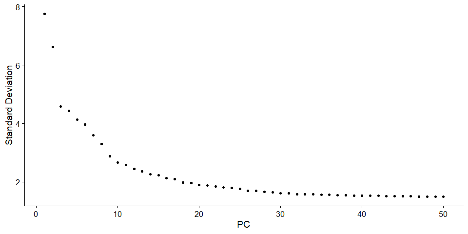

```r
set.seed(seed)
VariableFeatures(x) <- rownames(x)
x <-  ScaleData(x, verbose = FALSE)
x <- RunPCA(x, npcs = 50, verbose = FALSE)
ElbowPlot(x, ndims = 50)
```

We then run umap using the first 40 dimensions from PCA

```r
set.seed(seed)
x <- RunUMAP(x, reduction = "pca", dims = 1:40, verbose = FALSE)
```

# Plots

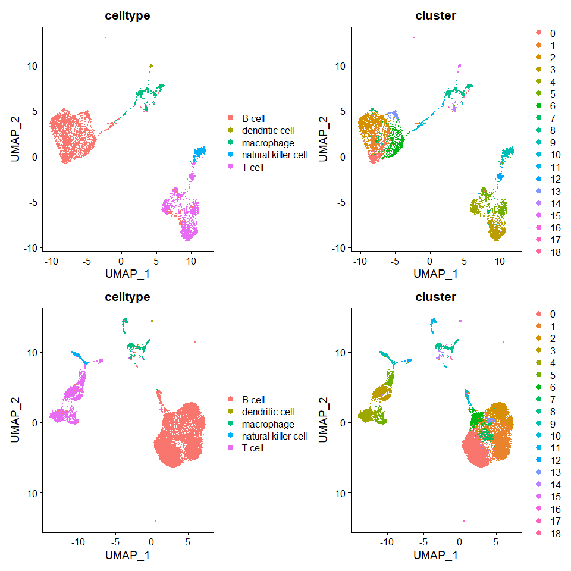

```r
Seurat::DimPlot(x, group.by = "celltype") + Seurat::DimPlot(x, group.by = "cluster") +
  Seurat::DimPlot(Uncorrected, group.by = "celltype") + Seurat::DimPlot(Uncorrected, group.by = "cluster")
```

# Calculate scores

We use the kBet and Silhouette to asses the bias introduced by integration tools. For comparison, we also assesed previous results from Figure 3 workflow of Canek’s paper.

```r
file <- here("Data/CanekPaper/Results/Figure3")
Canek <- readRDS(file = paste0(file, "/Canek2.Rds"))
Harmony <- readRDS(file = paste0(file, "/Harmony2.Rds"))
ComBat <- readRDS(file = paste0(file, "/ComBat2.Rds"))

scoSilhouette <- list()
scoKbet <- data.frame(NA, nrow = 3, ncol = 5)
colnames(scoKbet) <- c("Uncorrected", "Canek", "Harmony", "ComBat", "RISC")
```

[output not shown]

## Silhouette

We assesed the celltype preservations using the silhouette width score. We expect the scores from the integrations to be as close as possible to the ones from the uncorrected data.

```r
set.seed(seed)
dimPCA <- 40

scoSilhouette[["Uncorrected"]] <- RunSilhouette(object = Uncorrected, batch = "batch",
                                                reduction = "pca", nDim = dimPCA)
scoSilhouette[["Canek"]] <- RunSilhouette(object = Canek, batch = "batch",
                                          reduction = "pca", nDim = dimPCA)
scoSilhouette[["Harmony"]] <- RunSilhouette(object = Harmony, batch = "batch",
                                            reduction = "harmony", nDim = ncol(Harmony[["harmony"]]))
scoSilhouette[["ComBat"]] <- RunSilhouette(object = ComBat, batch = "batch",
                                           reduction = "pca", nDim = dimPCA)
scoSilhouette[["RISC"]] <- RunSilhouette(object = x, batch = "batch",
                                         reduction = "pca", nDim = dimPCA)

scoSilhouette <- as.data.frame(scoSilhouette)
scoSilhouette
```

| Uncorrected | Canek | Harmony | ComBat | RISC |
| --- | --- | --- | --- | --- |
| -1.288761e-05 | -7.188735e-06 | -0.0001152674 | -5.16248e-05 | -5.314012e-05 |

## kBET

We used kBET score to asses the mixing between batches. Again, we expect the scores to be as close as the one from the uncorrected data.

```r
scoKbet[,"Uncorrected"] <- RunKBET(object = Uncorrected, reduction = "pca", nDim = dimPCA,
                                   per = per, batch = "batch")
```

```
the condition has length > 1 and only the first element will be usedthe condition has length > 1 and only the first element will be usedthe condition has length > 1 and only the first element will be used
```

```r
scoKbet[,"Canek"] <- RunKBET(object = Canek, reduction = "pca", nDim = dimPCA,
                             per = per, batch = "batch")
```

```
the condition has length > 1 and only the first element will be usedthe condition has length > 1 and only the first element will be usedthe condition has length > 1 and only the first element will be used
```

```r
scoKbet[,"Harmony"] <- RunKBET(object = Harmony, reduction = "harmony",
                               nDim = ncol(Harmony[["harmony"]]),
                               per = per, batch = "batch")
```

```
the condition has length > 1 and only the first element will be usedthe condition has length > 1 and only the first element will be usedthe condition has length > 1 and only the first element will be used
```

```r
scoKbet[,"ComBat"] <- RunKBET(object = ComBat, reduction = "pca", nDim = dimPCA,
                              per = per, batch = "batch")
```

```
the condition has length > 1 and only the first element will be usedthe condition has length > 1 and only the first element will be usedthe condition has length > 1 and only the first element will be used
```

```r
scoKbet
```

```
     Uncorrected      Canek     Harmony     ComBat       RISC
[1,]  0.05638075 0.05588912 0.034759414 0.05164226 0.03925150
[2,]  0.03989540 0.03872385 0.012824268 0.03611925 0.01505988
[3,]  0.01399582 0.01428870 0.002332636 0.01941423 0.01122754
```

# Plot Scores

Finally, we plot the scores. The gray dashed lines represent the scores from the Uncorrected dataset, which on this case are the gold standard to achieve. We observe that RISC scored well on the celltype preservation (e.g. Silhouette score), but introduced some bias on the mixing of batches, as can be observed from the RISC’s kBET score as compared with the dashed line.

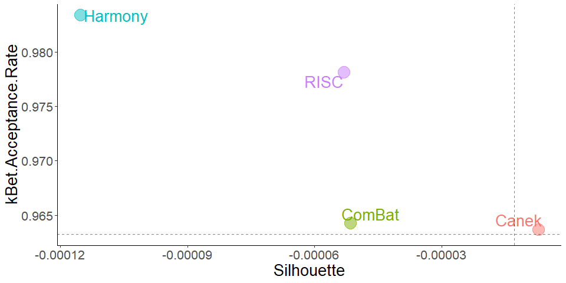

```r
scoSilhouette <- scoSilhouette[,colnames(scoKbet)]

df <- data.frame("Silhouette" = t(scoSilhouette), "kBet.Acceptance.Rate" = (1-colMeans(scoKbet)), method = colnames(scoKbet))

pd <- ggplot(df[-1,], aes(Silhouette, kBet.Acceptance.Rate, color = method, label = method)) +
  geom_point(size = 7, alpha = 0.5) +
  geom_text_repel(size = 7, alpha = 1.0, direction = "both", nudge_y = 0 ) +
  geom_hline(yintercept = df$kBet.Acceptance.Rate[1], linetype = "dashed", alpha = 0.5 ) +
  geom_vline(xintercept = df$Silhouette[1], linetype = "dashed", alpha = 0.5) + NoLegend()

pd
```

CONCLUSIONS: I got the feeling that RISC gives similar as ComBat ones. On the case of kBET and Silhouette scores, it obtained better results than Harmony. But I still have the impression that RISC results greatly depends on the choose of the reference batch.